# Comparison of FDR methods on 16S microbiome data with SummarizedBenchmark

Claire Duvallet

December 13, 2017

### Summary

In the previous document `cdi_schubert.Rmd`, we explored two microbiome datasets for FDR benchmarking. Here we will make use of the new `SummarizedBenchmark` package to perform the benchmarking in a standardized way.

### Workspace setup

```r
# project directory & data/results folders
setwd("/Users/claire/github/benchmark-fdr/datasets/microbiome/")
datdir <- "/Users/claire/github/benchmark-fdr/datasets/microbiome/DATA/"
resdir <- "/Users/claire/github/benchmark-fdr/datasets/microbiome/RESULTS/"

# wrangling & plotting tools
library(data.table)
#library(readxl)
library(dplyr)
library(ggplot2)
library(magrittr)
library(R.utils)
library(cowplot)

# benchmark methods
library(IHW)
library(ashr)
library(qvalue)
library(swfdr)
library(fdrtool)
library(FDRreg)

# comparison tools/functions
library(SummarizedBenchmark)
sourceDirectory("/Users/claire/github/benchmark-fdr/datasets/R/")

## set up parallel backend
library(BiocParallel)
cores <- as.numeric(Sys.getenv("SLURM_NTASKS"))
multicoreParam <- MulticoreParam(workers = cores)
```

Let’s just keep going and hopefully it’s okay…

### CDI Schubert - diarrhea dataset

Here we download and analyze the CDI Schubert diarrhea (C. diff and non-C.diff diarrhea) dataset. We’ll download the processed OTU tables from Zenodo and unzip them in the `benchmark-fdr/datasets/microbiome/DATA` folder.

#### Data download

```bash
cd /Users/claire/github/benchmark-fdr/datasets/microbiome/DATA/
curl -O "https://zenodo.org/record/840333/files/cdi_schubert_results.tar.gz"
tar -xzvf cdi_schubert_results.tar.gz
cd ..
```

Next, we’ll read in the unzipped OTU table and metadata files into R.

We’ll need to manually define which disease labels are of interest and what metadata column contains the sample IDs (i.e. the IDs in the OTU table).

```r
otu_path = paste0(datdir, "cdi_schubert_results/RDP/cdi_schubert.otu_table.100.denovo.rdp_assigned")
meta_path = paste0(datdir, "cdi_schubert_results/cdi_schubert.metadata.txt")

# DiseaseState labels to keep
labels <- c("H", "nonCDI", "CDI")

# Metadata column that has sample IDs
col_label <- 'sample_id'

# load OTU table and metadata
otu <- read.table(otu_path)
meta <- read.csv(meta_path, sep='\t')

# Keep only samples with the right DiseaseState metadata
meta <- meta %>% filter(DiseaseState %in% labels)

# Keep only samples with both metadata and 16S data
keep_samples <- intersect(colnames(otu), meta[, 1])
otu <- otu[, keep_samples]
meta <- meta %>% filter(get(col_label) %in% keep_samples)
```

Since we’ll be using OTU-wise covariates, we shouldn’t need to perform any filtering/cleaning of the OTUs, apart from removing any that are all zeros. (This may happen after removing shallow samples, I think.) However, let’s make sure we get rid of any samples with too few reads. We define the minimum number of reads per sample in `sample_reads`.

After we’ve removed any shallow samples, we’ll convert the OTU table to relative abundances. I’ll add a pseudo-count of 1e-6 to any zero entries, to avoid problems with taking logs.

```r
remove_shallow_smpls <- function(df, n_reads) {
  # Removes samples with fewer than n_reads from dataframe df.
  # df has OTUs in rows and samples in columns
  return(df[, colSums(df) > n_reads])
  }

remove_shallow_otus <- function(df, n_reads){
  return(df[rowSums(df) > n_reads, ])
  }

## Remove OTUs with fewere than 10 reads
#otu <- remove_shallow_otus(otu, 10)

# Remove samples with fewer than sample_Reads reads
sample_reads <- 100
otu <- remove_shallow_smpls(otu, sample_reads)

# Update metadata with new samples
meta <- meta %>% filter(get(col_label) %in% colnames(otu))

# Remove empty OTUs
otu <- otu[rowSums(otu) > 0, ]

# Convert to relative abundance
abun_otu <- t(t(otu) / rowSums(t(otu)))

# Add pseudo counts
#minabun <- min(abun_otu[abun_otu > 0]) # Use this to figure out what pseudo-count value to add
zeroabun <- 1e-6
abun_otu <- abun_otu + zeroabun
```

Next, we need to calculate the pvalues, effect size, and standard error for each OTU. Here, we’ll compare diarrhea vs. healthy. Diarrhea will include both CDI and nonCDI patients. We’ll put these results into a dataframe, and label the columns with the standardized names for downstream use (`pval`, `SE`, `effect_size`, `test_statistic`). The test statistic is the one returned by `wilcox.test()`.

Note that the effect here is calculated as logfold change of mean abundance in controls relative to cases (i.e. `log(mean_abun[controls]/mean_abun[cases])`)

While we’re at it, we’ll also calculate the mean abundance and ubiquity (detection rate) of each OTU. Later, we can assign their values to a new column called `ind_covariate` for use in downstream steps.

```r
resfile <- paste0(resdir, "schubert_results_",
                  nrow(abun_otu), "_OTUs.RData")
if (!file.exists(resfile)){
  # Get case and control indices
  case_idx <- meta$DiseaseState %in% c("CDI", "nonCDI")
  ctrl_idx <- meta$DiseaseState %in% c("H")

  # Calculate pvalues, effects, and stderr
  pvals <- c()
  teststats <- c()
  ses <- c()
  effs <- c()
  mean_abuns <- c()
  mean_abuns_present <- c()
  ubis <- c()

  casedf <- abun_otu[, case_idx]
  ctrldf <- abun_otu[, ctrl_idx]
  for (o in rownames(abun_otu)) {
    # wilcoxon p value
    w <- wilcox.test(casedf[o, ],
                     ctrldf[o, ])
    p <- w$p.value
    teststat <- w$statistic

    pvals <- c(pvals, p)
    teststats <- c(teststats, teststat)

    # standard error of the OTU abundance, across all samples
    ses <- c(ses,
             sd(abun_otu[o, ])/sqrt(length(abun_otu[o, ]))
             )

    # mean OTU abundance across all samples (after removing pseudo-count)
    mean_abuns <- c(mean_abuns,
                    mean(abun_otu[o, ] - zeroabun)
                    )

    # mean OTU abundance across only samples with the OTU present
    mean_abuns_present <- c(mean_abuns_present,
                            sum(abun_otu[o, ] - zeroabun) / sum(abun_otu[o, ] > zeroabun)
                            )

    # ubiquity of OTU across all samples
    ubis <- c(ubis,
              sum(abun_otu[o, ] > zeroabun) / length(abun_otu[o, ])
              )

    # effect (logfold difference)
    effs <- c(effs,
              log(mean(abun_otu[o, ctrl_idx])/mean(abun_otu[o, case_idx]))
              )

  }

  res <- data.frame(otu = rownames(abun_otu),
                    pval = pvals, test_statistic = teststats,
                    SE = ses, effect_size = effs,
                    mean_abun = mean_abuns, mean_abun_present = mean_abuns_present,
                    ubiquity = ubis)
  save(res, file=resfile)

}else{
  load(resfile)
}
head(res)
```

```
##                                                                                                                       otu
## 1       k__Bacteria;p__Firmicutes;c__Negativicutes;o__Selenomonadales;f__Veillonellaceae;g__Veillonella;s__;d__denovo5393
## 2               k__Bacteria;p__Firmicutes;c__Clostridia;o__Clostridiales;f__Lachnospiraceae;g__Blautia;s__;d__denovo16247
## 3 k__Bacteria;p__Bacteroidetes;c__Bacteroidia;o__Bacteroidales;f__Porphyromonadaceae;g__Parabacteroides;s__;d__denovo1106
## 4                      k__Bacteria;p__Firmicutes;c__Clostridia;o__Clostridiales;f__Ruminococcaceae;g__;s__;d__denovo15568
## 5         k__Bacteria;p__Bacteroidetes;c__Bacteroidia;o__Bacteroidales;f__Bacteroidaceae;g__Bacteroides;s__;d__denovo5395
## 6         k__Bacteria;p__Bacteroidetes;c__Bacteroidia;o__Bacteroidales;f__Bacteroidaceae;g__Bacteroides;s__;d__denovo3059
##           pval test_statistic           SE effect_size    mean_abun
## 1 0.0650398103        14322.0 4.955526e-06  -2.6508094 7.131312e-06
## 2 0.1246671429        13832.0 1.174467e-06   1.5147323 1.626260e-06
## 3 0.0007407769        12489.0 5.579883e-06   0.6075952 2.620864e-05
## 4 0.1246671429        13832.0 8.315416e-07   1.2601725 1.157764e-06
## 5 0.0339394922        13548.0 1.138297e-06   1.0520522 2.907206e-06
## 6 0.0012890518        13095.5 2.568475e-06   1.3350667 7.632848e-06
##   mean_abun_present    ubiquity
## 1      0.0005990302 0.011904762
## 2      0.0002732117 0.005952381
## 3      0.0002751907 0.095238095
## 4      0.0001945043 0.005952381
## 5      0.0001395459 0.020833333
## 6      0.0002137198 0.035714286
```

Finally, let’s try to add phylogeny as covariates. Here we’ll have columns for each separate taxonomic level.

```r
res <- res %>% separate(otu,
                        c("kingdom", "phylum", "class", "order", "family", "genus", "species", "denovo"),
                        sep=";", remove = FALSE)
```

#### Check Covariate Diagnostics

Here we look to see if the covariates do indeed look informative.

##### Ubiquity

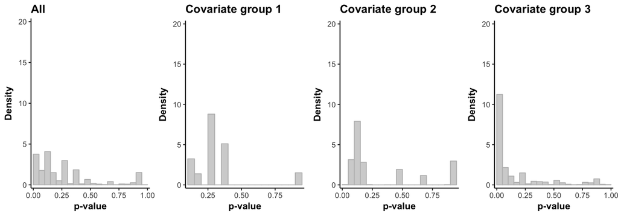

```r
strat_hist(res, pvalue="pval", covariate="ubiquity", maxy=20, binwidth=0.05)
```

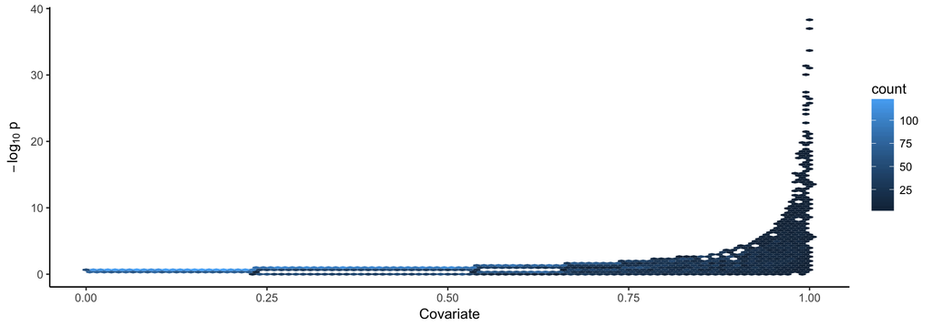

```r
rank_scatter(res, pvalue="pval", covariate="ubiquity")
```

##### Mean abundance (across non-zero samples)

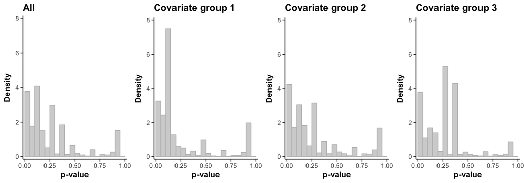

```r
strat_hist(res, pvalue="pval", covariate="mean_abun_present", maxy=8, binwidth=0.05)
```

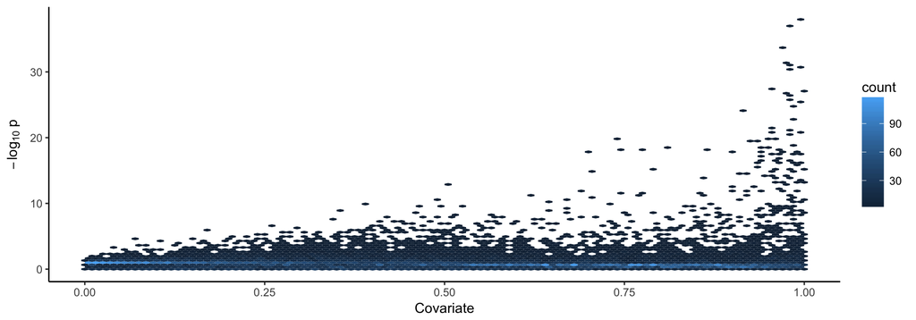

```r
rank_scatter(res, pvalue="pval", covariate="mean_abun_present")
```

##### Phylogeny?!

Let’s look at phylum-level stratification first. A priori, I *might* expect Proteobacteria to be enriched for low p-values? But I don’t know if that’s super legit, and Eric doesn’t seem to think that phylogeny will be informative at all…

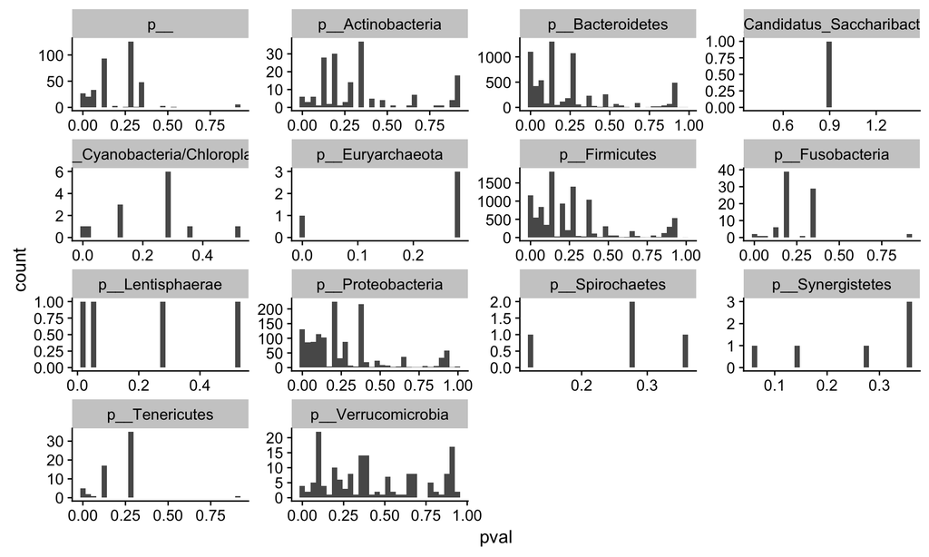

```r
#strat_hist(res, pvalue="pval", covariate="mean_abun_present", maxy=20)
#rank_scatter(res, pvalue="pval", covariate="ubiquity")
ggplot(res, aes(x=pval)) + geom_histogram() + facet_wrap(~phylum, scales = "free")
```

Let’s use `ubiquity` as our `ind_covariate`

```r
res <- res %>% mutate(ind_covariate = ubiquity)
```

#### Set up BenchDesign object

First, we’ll create an object of `BenchDesign` class to hold the data and add the benchmark methods to the `BenchDesign` object. We’ll do this for a few values of nmids, to explore its effects on the outputs.

Then, we’ll construct the `SummarizedBenchmark` object, which will run the functions specified in each method (these are actually sourced in from the helper scripts).

```r
for (nmids in c(5, 50, 150)){
  print(nmids)
  bd <- initializeBenchDesign(nmids=nmids)

  resfile <- paste0(resdir, "schubert_summarizedBenchmark_",
                    nrow(res), "_nmids_", nmids, ".RData")
  duration <- NA
  if (!file.exists(resfile)){
    t1 <- proc.time()
    sb <- bd %>% buildBench(data=res, ftCols = "ind_covariate")
                            #parallel=TRUE, BPPARAM=multicoreParam)
    metadata(sb)$data_download_link <- "https://zenodo.org/record/840333/files/cdi_schubert_results.tar.gz"
    save(sb, file=resfile)
    duration <- round((proc.time()-t1)[3]/60,1)
  }else{
    load(resfile)
  }
}
```

Just for future runs, where I load the file instead of re-calculating it, here are the errors I got:

```
[1] 5
Censored sample for null model estimation has only size 0 !Censored sample for null model estimation has only size 0 !Censored sample for null model estimation has only size 0 !Censored sample for null model estimation has only size 0 !NaNs produced<simpleError in if (sum(D^2) > qchisq(0.9, nmids - …

[1] 50
Censored sample for null model estimation has only size 0 !Censored sample for null model estimation has only size 0 !Censored sample for null model estimation has only size 0 !Censored sample for null model estimation has only size 0 !f(z) misfit = -21.6.  Rerun with increased df.f(z) misfit = -22.…

[1] 150
Censored sample for null model estimation has only size 0 !Censored sample for null model estimation has only size 0 !Censored sample for null model estimation has only size 0 !Censored sample for null model estimation has only size 0 !f(z) misfit = 83.4.  Rerun with increased df.f(z) misfit = -8.5.…
```

Next, we’ll add the default performance metric for q-value assays. First, we have to rename the assay to ‘qvalue’.

```r
# rename assay to qvalue
assayNames(sb) <- "qvalue"
sb <- addDefaultMetrics(sb)
```

Now, we’ll plot the results.

Debugging note: to look at the matrix of qvalues, run `assays(sb)[["qvalue"]]`

```r
# don't plot scott theoretical for now
rmv.scott <- which(grepl("scott", colnames(sb)))

# plot nrejects by method overall and stratified by covariate
rejections_scatter(sb, as_fraction=FALSE, supplementary=FALSE)

rejection_scatter_bins(sb, covariate="ind_covariate", bins=4, supplementary=FALSE)

# upset plot (only plot IHW for the plotted alpha)
rmv.ihw <- which(grepl("ihw", colnames(sb)) &
                              colData(sb)$param.alpha != 0.05)
rmv.cols <- c(rmv.ihw, rmv.scott)

plotMethodsOverlap(sb[,-rmv.cols],
                   alpha=0.05, nsets=ncol(sb)-length(rmv.cols),
                   order.by="freq", decreasing=TRUE)

# upset plot excluding "unadjusted"
plotMethodsOverlap(sb[,-c(1,rmv.cols)],
                   alpha=0.05, nsets=ncol(sb)-length(rmv.cols)-1,
                   order.by="freq", decreasing=TRUE)
```

[output not shown]

```r
assays(sb)[["qvalue"]][ , 15] %>% max()
sum(is.na(assays(sb)[["qvalue"]][ , 22]))
sum(is.na(assays(sb)[["qvalue"]][ , 20]))
```

Rather than de-bug this dataset (which might be weird), let’s try instead to work with the obesity dataset and see if I get the same problems.

And we’ll clean up the workspace before moving on to the next dataset.

```r
rm(res)
rm(bd)
rm(sb)
rm(pf)
```

### OB Goodrich - obesity dataset

Let’s repeat these analyses for the OB Goodrich dataset.

#### Data download

```bash
cd /Users/claire/github/benchmark-fdr/datasets/microbiome/DATA/
curl -O "https://zenodo.org/record/840333/files/ob_goodrich_results.tar.gz"
tar -xzvf ob_goodrich_results.tar.gz
cd ..
```

Next, we’ll read in the unzipped OTU table and metadata files into R.

We’ll need to manually define which disease labels are of interest and what metadata column contains the sample IDs (i.e. the IDs in the OTU table).

```r
otu_path = paste0(datdir, "ob_goodrich_results/RDP/ob_goodrich.otu_table.100.denovo.rdp_assigned")
meta_path = paste0(datdir, "ob_goodrich_results/ob_goodrich.metadata.txt")

# DiseaseState labels to keep
labels <- c("H", "OB")

# Metadata column that has sample IDs
col_label <- "X"

# load OTU table and metadata
otu <- read.table(otu_path)
meta <- read.csv(meta_path, sep='\t')

# Keep only samples with the right DiseaseState metadata
meta <- meta %>% filter(DiseaseState %in% labels)

# Keep only samples with both metadata and 16S data
keep_samples <- intersect(colnames(otu), meta[, 1])
otu <- otu[, keep_samples]
meta <- meta %>% filter(get(col_label) %in% keep_samples)
```

Since we’ll be using OTU-wise covariates, we shouldn’t need to perform any filtering/cleaning of the OTUs, apart from removing any that are all zeros. (This may happen after removing shallow samples, I think.) However, let’s make sure we get rid of any samples with too few reads. We define the minimum number of reads per sample in `sample_reads`.

After we’ve removed any shallow samples, we’ll convert the OTU table to relative abundances. I’ll add a pseudo-count of 1e-6 to any zero entries, to avoid problems with taking logs.

```r
remove_shallow_smpls <- function(df, n_reads) {
  # Removes samples with fewer than n_reads from dataframe df.
  # df has OTUs in rows and samples in columns
  return(df[, colSums(df) > n_reads])
  }

# Remove samples with fewer than sample_Reads reads
sample_reads <- 100
otu <- remove_shallow_smpls(otu, sample_reads)

# Update metadata with new samples
meta <- meta %>% filter(get(col_label) %in% colnames(otu))

# Remove empty OTUs
otu <- otu[rowSums(otu) > 0, ]

# Convert to relative abundance
abun_otu <- t(t(otu) / rowSums(t(otu)))

# Add pseudo counts
#minabun <- min(abun_otu[abun_otu > 0]) # Use this to figure out what pseudo-count value to add
zeroabun <- 1e-6
abun_otu <- abun_otu + zeroabun
```

Next, we need to calculate the pvalues, effect size, and standard error for each OTU. Here, we’ll compare lean vs. obese. We’ll put these results into a dataframe, and label the columns with the standardized names for downstream use (`pval`, `SE`, `effect_size`, `test_statistic`). The test statistic is the one returned by `wilcox.test()`.

Note that the effect here is calculated as logfold change of mean abundance in controls relative to cases (i.e. `log(mean_abun[controls]/mean_abun[cases])`)

While we’re at it, we’ll also calculate the mean abundance and ubiquity (detection rate) of each OTU. Later, we can assign their values to a new column called `ind_covariate` for use in downstream steps.

Note that OB Goodrich has ~70,000 OTUs, so this is going to take a while. There are probably faster ways to write this, but I don’t know them.

```r
dim(abun_otu)
```

```
## [1] 71710   644
```

```r
resfile <- paste0(resdir, "goodrich_results_",
                  nrow(abun_otu), "_OTUs.RData")
if (!file.exists(resfile)){
  # Get case and control indices
  case_idx <- meta$DiseaseState %in% c("OB")
  ctrl_idx <- meta$DiseaseState %in% c("H")

  # Calculate pvalues, effects, and stderr
  pvals <- c()
  teststats <- c()
  ses <- c()
  effs <- c()
  mean_abuns <- c()
  mean_abuns_present <- c()
  ubis <- c()

  casedf <- abun_otu[, case_idx]
  ctrldf <- abun_otu[, ctrl_idx]
  for (o in rownames(abun_otu)) {
    # wilcoxon p value
    w <- wilcox.test(casedf[o, ],
                     ctrldf[o, ])
    p <- w$p.value
    teststat <- w$statistic

    pvals <- c(pvals, p)
    teststats <- c(teststats, teststat)

    # standard error of the OTU abundance, across all samples
    ses <- c(ses,
             sd(abun_otu[o, ])/sqrt(length(abun_otu[o, ]))
             )

    # mean OTU abundance across all samples (after removing pseudo-count)
    mean_abuns <- c(mean_abuns,
                    mean(abun_otu[o, ] - zeroabun)
                    )

    # mean OTU abundance across only samples with the OTU present
    mean_abuns_present <- c(mean_abuns_present,
                            sum(abun_otu[o, ] - zeroabun) / sum(abun_otu[o, ] > zeroabun)
                            )

    # ubiquity of OTU across all samples
    ubis <- c(ubis,
              sum(abun_otu[o, ] > zeroabun) / length(abun_otu[o, ])
              )

    # effect (logfold difference)
    effs <- c(effs,
              log(mean(abun_otu[o, ctrl_idx])/mean(abun_otu[o, case_idx]))
              )

  }

  res <- data.frame(otu = rownames(abun_otu),
                    pval = pvals, test_statistic = teststats,
                    SE = ses, effect_size = effs,
                    mean_abun = mean_abuns, mean_abun_present = mean_abuns_present,
                    ubiquity = ubis)
  save(res, file=resfile)

}else{
  load(resfile)
}
head(res)
```

```
##                                                                                                                                                   otu
## 1                        k__Bacteria;p__Firmicutes;c__Erysipelotrichia;o__Erysipelotrichales;f__Erysipelotrichaceae;g__Turicibacter;s__;d__denovo7357
## 2                                    k__Bacteria;p__Bacteroidetes;c__Bacteroidia;o__Bacteroidales;f__Bacteroidaceae;g__Bacteroides;s__;d__denovo43273
## 3 k__Bacteria;p__Firmicutes;c__Erysipelotrichia;o__Erysipelotrichales;f__Erysipelotrichaceae;g__Erysipelotrichaceae_incertae_sedis;s__;d__denovo53708
## 4           k__Bacteria;p__Proteobacteria;c__Gammaproteobacteria;o__Enterobacteriales;f__Enterobacteriaceae;g__Escherichia/Shigella;s__;d__denovo5395
## 5                                  k__Bacteria;p__Firmicutes;c__Clostridia;o__Clostridiales;f__Ruminococcaceae;g__Faecalibacterium;s__;d__denovo22216
## 6                                    k__Bacteria;p__Bacteroidetes;c__Bacteroidia;o__Bacteroidales;f__Bacteroidaceae;g__Bacteroides;s__;d__denovo11290
##        pval test_statistic           SE effect_size    mean_abun
## 1 0.5000965        42785.5 1.052393e-06   0.4505973 5.641971e-06
## 2 0.1418748        44005.0 1.320552e-07  -0.2934101 2.763841e-07
## 3 0.1427017        43039.0 1.035153e-07   0.2777221 2.241829e-07
## 4 0.6519241        43052.0 1.055702e-06   0.5889331 5.667916e-06
## 5 0.2753310        42795.0 4.031273e-07  -0.2416092 1.237534e-06
## 6 0.8367976        43421.0 1.142114e-06   0.7892902 2.089385e-06
##   mean_abun_present    ubiquity
## 1      6.055715e-05 0.093167702
## 2      3.559827e-05 0.007763975
## 3      2.887476e-05 0.007763975
## 4      6.759514e-05 0.083850932
## 5      3.795106e-05 0.032608696
## 6      1.223240e-04 0.017080745
```

Finally, let’s try to add phylogeny as covariates. Here we’ll have columns for each separate taxonomic level.

```r
res <- res %>% separate(otu,
                        c("kingdom", "phylum", "class", "order", "family", "genus", "species", "denovo"),
                        sep=";", remove = FALSE)
```

#### Check Covariate Diagnostics

Here we look to see if the covariates do indeed look informative.

##### Ubiquity

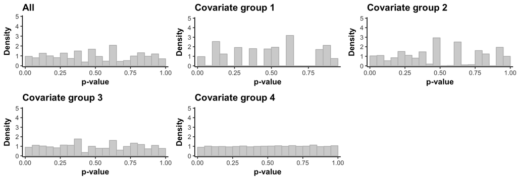

```r
strat_hist(res, pvalue="pval", covariate="ubiquity", maxy=5, binwidth=0.05, numQ=4)
```

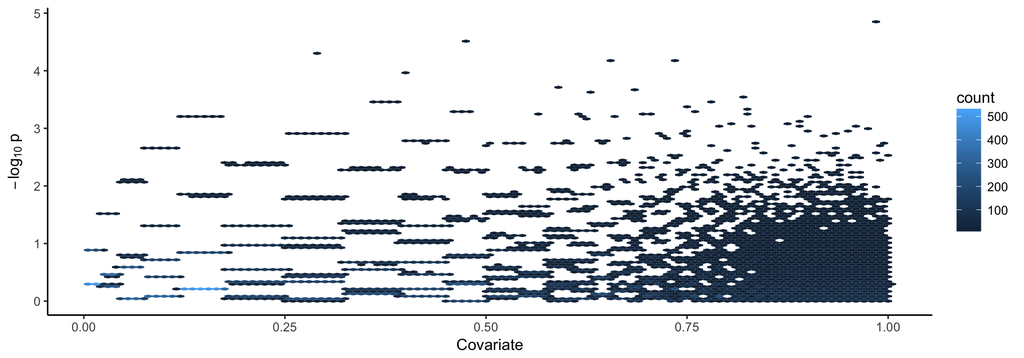

```r
rank_scatter(res, pvalue="pval", covariate="ubiquity")
```

##### Mean abundance (across non-zero samples)

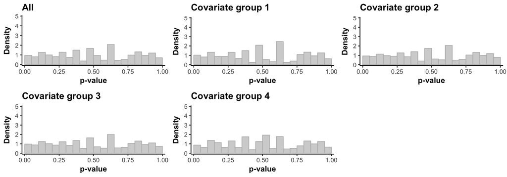

```r
strat_hist(res, pvalue="pval", covariate="mean_abun_present", maxy=5, binwidth=0.05, numQ=4)
```

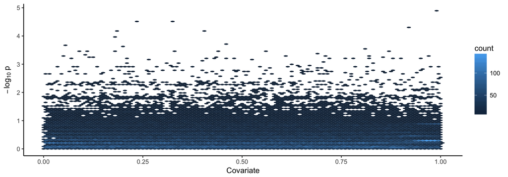

```r
rank_scatter(res, pvalue="pval", covariate="mean_abun_present")
```

##### Phylogeny?!

Let’s look at phylum-level stratification first. A priori, I *might* expect Proteobacteria to be enriched for low p-values? But I don’t know if that’s super legit, and Eric doesn’t seem to think that phylogeny will be informative at all…

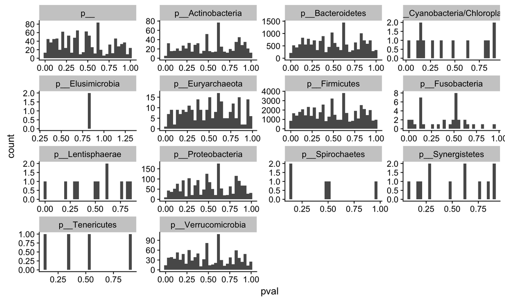

```r
#strat_hist(res, pvalue="pval", covariate="mean_abun_present", maxy=20)
#rank_scatter(res, pvalue="pval", covariate="ubiquity")
ggplot(res, aes(x=pval)) + geom_histogram() + facet_wrap(~phylum, scales = "free")
```

Let’s use `ubiquity` as our `ind_covariate`

```r
res <- res %>% mutate(ind_covariate = ubiquity)
```

#### Set up BenchDesign object

First, we’ll create an object of `BenchDesign` class to hold the data and add the benchmark methods to the `BenchDesign` object.

Next, we’ll construct the `SummarizedBenchmark` object, which will run the functions specified in each method (these are actually sourced in from the helper scripts).

```r
for (nmids in c(5, 50, 150)){
  print(nmids)
  bd <- initializeBenchDesign(nmids=nmids)

  resfile <- paste0(resdir, "goodrich_summarizedBenchmark_",
                    nrow(res), "_nmids_", nmids, ".RData")
  duration <- NA
  if (!file.exists(resfile)){
    t1 <- proc.time()
    sb <- bd %>% buildBench(data=res, ftCols = "ind_covariate")
                            #parallel=TRUE, BPPARAM=multicoreParam)
    metadata(sb)$data_download_link <- "https://zenodo.org/record/840333/files/cdi_schubert_results.tar.gz"
    save(sb, file=resfile)
    duration <- round((proc.time()-t1)[3]/60,1)
  }else{
    load(resfile)
  }
}
```

The outputs of this call are:

[output not shown]

Next, we’ll add the default performance metric for q-value assays. First, we have to rename the assay to ‘qvalue’.

```r
# rename assay to qvalue
assayNames(sb) <- "qvalue"
sb <- addDefaultMetrics(sb)
```

Now, we’ll plot the results.

Debugging note: to look at the matrix of qvalues, run `assays(sb)[["qvalue"]]`

```r
# plot nrejects by method overall and stratified by covariate
rejections_scatter(sb, as_fraction=FALSE, supplementary=FALSE)

rejection_scatter_bins(sb, covariate="ind_covariate", bins=4, supplementary=FALSE)

# upset plot (only plot IHW for the plotted alpha)
rmv.ihw <- which(grepl("ihw", colnames(sb)) &
                              colData(sb)$param.alpha != 0.05)

plotMethodsOverlap(sb[,-rmv.ihw],
                   alpha=0.05, nsets=ncol(sb)-length(rmv.ihw),
                   order.by="freq", decreasing=TRUE)

# upset plot excluding "unadjusted"
plotMethodsOverlap(sb[,-c(1,rmv.ihw)],
                   alpha=0.05, nsets=ncol(sb)-length(rmv.ihw)-1,
                   order.by="freq", decreasing=TRUE)
```

[output not shown]

```r
assays(sb)[["qvalue"]][, "ashs"] %>% max()
sum(is.na(assays(sb)[["qvalue"]][, "scott-empirical"]))
sum(is.na(assays(sb)[["qvalue"]][, "lfdr"]))
```

### CRC Baxter - colorectal cancer

Next, I’ll look at the CRC Baxter dataset. For colorectal cancer, we do expect some amount of truly differentially abundant OTUs, but not as many as in diarrhea. This dataset will hopefully provide an intermediate non-extreme case study. We’ll download the processed OTU tables from Zenodo and unzip them in the `benchmark-fdr/datasets/microbiome/DATA` folder.

#### Data download

```bash
cd /Users/claire/github/benchmark-fdr/datasets/microbiome/DATA/
curl -O "https://zenodo.org/record/840333/files/crc_baxter_results.tar.gz"
tar -xzvf crc_baxter_results.tar.gz
cd ..
```

Next, we’ll read in the unzipped OTU table and metadata files into R.

We’ll need to manually define which disease labels are of interest and what metadata column contains the sample IDs (i.e. the IDs in the OTU table).

```r
otu_path = paste0(datdir, "crc_baxter_results/RDP/crc_baxter.otu_table.100.denovo.rdp_assigned")
meta_path = paste0(datdir, "crc_baxter_results/crc_baxter.metadata.txt")

# DiseaseState labels to keep
labels <- c("H", "CRC")

# Metadata column that has sample IDs
col_label <- "Sample_Name_s"

# load OTU table and metadata
otu <- read.table(otu_path)
meta <- read.csv(meta_path, sep='\t')

# Keep only samples with the right DiseaseState metadata
meta <- meta %>% filter(DiseaseState %in% labels)

# Add "X" in front of sample IDs because of how R read in the OTU table
meta[, 1] <- sub("^", "X", meta[, 1])

# Keep only samples with both metadata and 16S data
keep_samples <- intersect(colnames(otu), meta[, 1])
otu <- otu[, keep_samples]
meta <- meta %>% filter(get(col_label) %in% keep_samples)
```

Since we’ll be using OTU-wise covariates, we shouldn’t need to perform any filtering/cleaning of the OTUs, apart from removing any that are all zeros. (This may happen after removing shallow samples, I think.) However, let’s make sure we get rid of any samples with too few reads. We define the minimum number of reads per sample in `sample_reads`.

After we’ve removed any shallow samples, we’ll convert the OTU table to relative abundances. I’ll add a pseudo-count of 1e-7 to any zero entries, to avoid problems with taking logs.

```r
remove_shallow_smpls <- function(df, n_reads) {
  # Removes samples with fewer than n_reads from dataframe df.
  # df has OTUs in rows and samples in columns
  return(df[, colSums(df) > n_reads])
  }

remove_shallow_otus <- function(df, n_reads){
  return(df[rowSums(df) > n_reads, ])
  }

## Remove OTUs with fewere than 10 reads
#otu <- remove_shallow_otus(otu, 10)

# Remove samples with fewer than sample_Reads reads
sample_reads <- 100
otu <- remove_shallow_smpls(otu, sample_reads)

# Update metadata with new samples
meta <- meta %>% filter(get(col_label) %in% colnames(otu))

# Remove empty OTUs
otu <- otu[rowSums(otu) > 0, ]

# Convert to relative abundance
abun_otu <- t(t(otu) / rowSums(t(otu)))

# Add pseudo counts
#minabun <- min(abun_otu[abun_otu > 0]) # Use this to figure out what pseudo-count value to add
zeroabun <- 1e-7
abun_otu <- abun_otu + zeroabun
```

Next, we need to calculate the pvalues, effect size, and standard error for each OTU. Here, we’ll compare CRC vs. healthy. We won’t consider the nonCRC adenoma patients. We’ll put these results into a dataframe, and label the columns with the standardized names for downstream use (`pval`, `SE`, `effect_size`, `test_statistic`). The test statistic is the one returned by `wilcox.test()`.

Note that the effect here is calculated as logfold change of mean abundance in controls relative to cases (i.e. `log(mean_abun[controls]/mean_abun[cases])`)

While we’re at it, we’ll also calculate the mean abundance and ubiquity (detection rate) of each OTU. Later, we can assign their values to a new column called `ind_covariate` for use in downstream steps.

```r
resfile <- paste0(resdir, "baxter_results_",
                  nrow(abun_otu), "_OTUs.RData")
if (!file.exists(resfile)){
  # Get case and control indices
  case_idx <- meta$DiseaseState %in% c("CRC")
  ctrl_idx <- meta$DiseaseState %in% c("H")

  # Calculate pvalues, effects, and stderr
  pvals <- c()
  teststats <- c()
  ses <- c()
  effs <- c()
  mean_abuns <- c()
  mean_abuns_present <- c()
  ubis <- c()

  casedf <- abun_otu[, case_idx]
  ctrldf <- abun_otu[, ctrl_idx]
  for (o in rownames(abun_otu)) {
    # wilcoxon p value
    w <- wilcox.test(casedf[o, ],
                     ctrldf[o, ])
    p <- w$p.value
    teststat <- w$statistic

    pvals <- c(pvals, p)
    teststats <- c(teststats, teststat)

    # standard error of the OTU abundance, across all samples
    ses <- c(ses,
             sd(abun_otu[o, ])/sqrt(length(abun_otu[o, ]))
             )

    # mean OTU abundance across all samples (after removing pseudo-count)
    mean_abuns <- c(mean_abuns,
                    mean(abun_otu[o, ] - zeroabun)
                    )

    # mean OTU abundance across only samples with the OTU present
    mean_abuns_present <- c(mean_abuns_present,
                            sum(abun_otu[o, ] - zeroabun) / sum(abun_otu[o, ] > zeroabun)
                            )

    # ubiquity of OTU across all samples
    ubis <- c(ubis,
              sum(abun_otu[o, ] > zeroabun) / length(abun_otu[o, ])
              )

    # effect (logfold difference)
    effs <- c(effs,
              log(mean(abun_otu[o, ctrl_idx])/mean(abun_otu[o, case_idx]))
              )

  }

  res <- data.frame(otu = rownames(abun_otu),
                    pval = pvals, test_statistic = teststats,
                    SE = ses, effect_size = effs,
                    mean_abun = mean_abuns, mean_abun_present = mean_abuns_present,
                    ubiquity = ubis)
  save(res, file=resfile)

}else{
  load(resfile)
}
head(res)
```

```
##                                                                                                                otu
## 1 k__Bacteria;p__Bacteroidetes;c__Bacteroidia;o__Bacteroidales;f__Bacteroidaceae;g__Bacteroides;s__;d__denovo84068
## 2   k__Bacteria;p__Firmicutes;c__Clostridia;o__Clostridiales;f__Ruminococcaceae;g__Ruminococcus;s__;d__denovo84069
## 3  k__Bacteria;p__Firmicutes;c__Bacilli;o__Lactobacillales;f__Lactobacillaceae;g__Lactobacillus;s__;d__denovo84067
## 4          k__Bacteria;p__Firmicutes;c__Clostridia;o__Clostridiales;f__Lachnospiraceae;g__Dorea;s__;d__denovo84062
## 5 k__Bacteria;p__Bacteroidetes;c__Bacteroidia;o__Bacteroidales;f__Bacteroidaceae;g__Bacteroides;s__;d__denovo84063
## 6 k__Bacteria;p__Firmicutes;c__Clostridia;o__Clostridiales;f__Ruminococcaceae;g__Clostridium_IV;s__;d__denovo84060
##        pval test_statistic           SE effect_size    mean_abun
## 1 0.4074958          10260 6.846166e-08   0.7711521 6.846166e-08
## 2 0.2339448          10406 3.645580e-07  -2.2895921 3.645580e-07
## 3 0.2339448          10406 9.453851e-08  -1.1940549 9.453851e-08
## 4 0.4074958          10260 7.340387e-07   2.5998402 7.340387e-07
## 5 0.2339448          10406 1.631916e-07  -1.6036202 1.631916e-07
## 6 0.2339448          10406 1.204678e-07  -1.3689911 1.204678e-07
##   mean_abun_present    ubiquity
## 1      1.999080e-05 0.003424658
## 2      1.064509e-04 0.003424658
## 3      2.760524e-05 0.003424658
## 4      2.143393e-04 0.003424658
## 5      4.765195e-05 0.003424658
## 6      3.517659e-05 0.003424658
```

Finally, let’s try to add phylogeny as covariates. Here we’ll have columns for each separate taxonomic level.

```r
res <- res %>% separate(otu,
                        c("kingdom", "phylum", "class", "order", "family", "genus", "species", "denovo"),
                        sep=";", remove = FALSE)
```

#### Check Covariate Diagnostics

Here we look to see if the covariates do indeed look informative.

##### Ubiquity

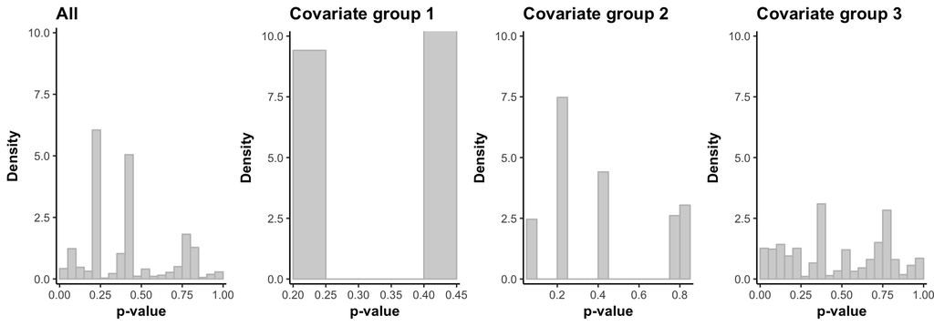

```r
strat_hist(res, pvalue="pval", covariate="ubiquity", maxy=10, binwidth=0.05)
```

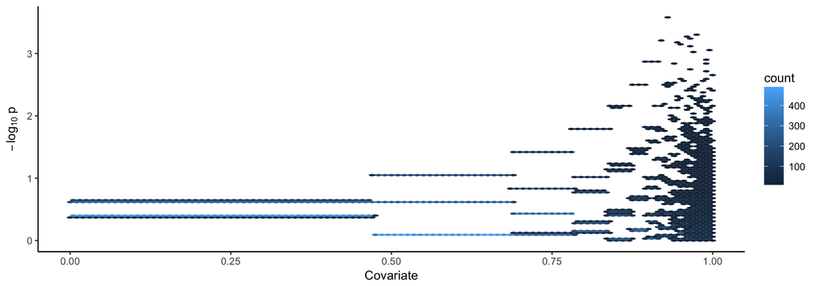

```r
rank_scatter(res, pvalue="pval", covariate="ubiquity")
```

Something weird is happening with p=0.20 and p=0.40 - maybe this has something to do with ties? Either way, ubiquity looks to be a bit informative (from the scatter plot, but not really the histograms…)

##### Mean abundance (across non-zero samples)

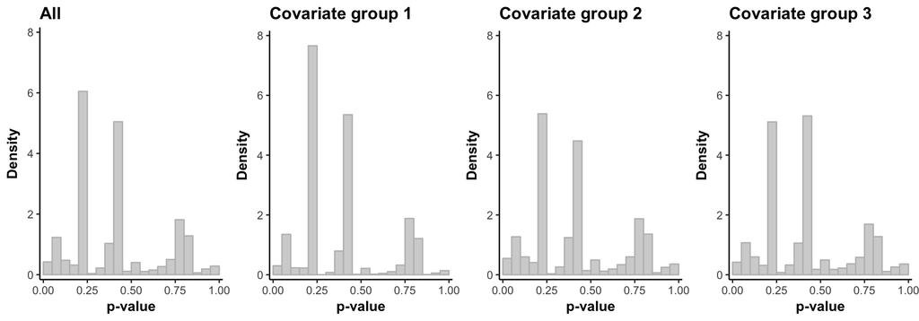

```r
strat_hist(res, pvalue="pval", covariate="mean_abun_present", maxy=8, binwidth=0.05)
```

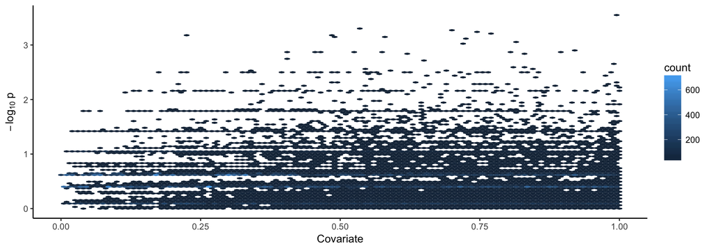

```r
rank_scatter(res, pvalue="pval", covariate="mean_abun_present")
```

##### Phylogeny?!

Let’s look at phylum-level stratification first. A priori, I *might* expect Proteobacteria to be enriched for low p-values? But I don’t know if that’s super legit, and Eric doesn’t seem to think that phylogeny will be informative at all…

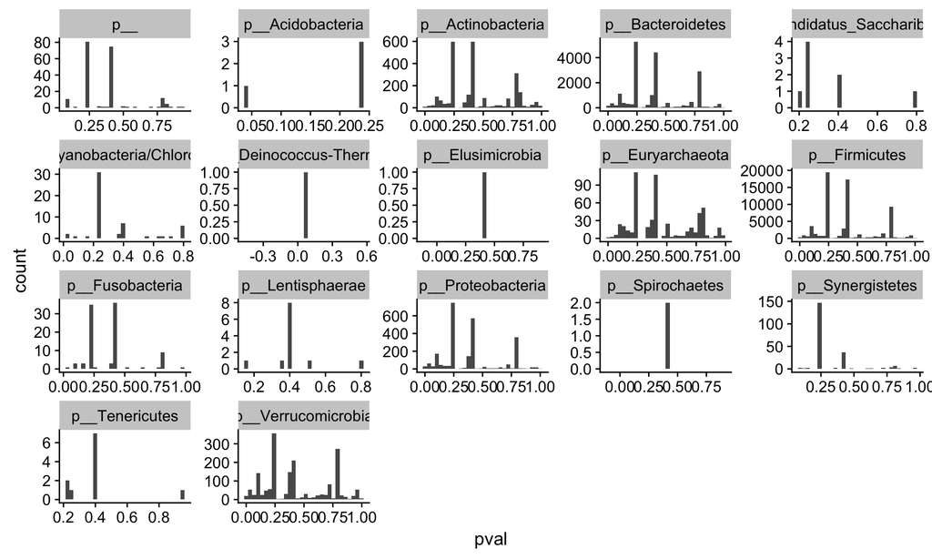

```r
#strat_hist(res, pvalue="pval", covariate="mean_abun_present", maxy=20)
#rank_scatter(res, pvalue="pval", covariate="ubiquity")
ggplot(res, aes(x=pval)) + geom_histogram() + facet_wrap(~phylum, scales = "free")
```

Not really informative either…

Let’s use `ubiquity` as our `ind_covariate`

```r
res <- res %>% mutate(ind_covariate = ubiquity)
```

#### Set up BenchDesign object

First, we’ll create an object of `BenchDesign` class to hold the data and add the benchmark methods to the `BenchDesign` object. We’ll do this for a few values of nmids, to explore its effects on the outputs.

Then, we’ll construct the `SummarizedBenchmark` object, which will run the functions specified in each method (these are actually sourced in from the helper scripts).

```r
for (nmids in c(5, 50, 150)){
  print(nmids)
  bd <- initializeBenchDesign(nmids=nmids)

  resfile <- paste0(resdir, "baxter_summarizedBenchmark_",
                    nrow(res), "_nmids_", nmids, ".RData")
  duration <- NA
  if (!file.exists(resfile)){
    t1 <- proc.time()
    sb <- bd %>% buildBench(data=res, ftCols = "ind_covariate")
                            #parallel=TRUE, BPPARAM=multicoreParam)
    metadata(sb)$data_download_link <- "https://zenodo.org/record/840333/files/crc_baxter_results.tar.gz"
    save(sb, file=resfile)
    duration <- round((proc.time()-t1)[3]/60,1)
  }else{
    load(resfile)
  }
}
```

Just for future runs, where I load the file instead of re-calculating it, here are the errors I got:

[output not shown]

Next, we’ll add the default performance metric for q-value assays. First, we have to rename the assay to ‘qvalue’.

```r
# rename assay to qvalue
assayNames(sb) <- "qvalue"
sb <- addDefaultMetrics(sb)
```

Now, we’ll plot the results.

Debugging note: to look at the matrix of qvalues, run `assays(sb)[["qvalue"]]`

```r
# don't plot scott theoretical for now
rmv.scott <- which(grepl("scott", colnames(sb)))

# plot nrejects by method overall and stratified by covariate
rejections_scatter(sb, as_fraction=FALSE, supplementary=FALSE)

rejection_scatter_bins(sb, covariate="ind_covariate", bins=4, supplementary=FALSE)

# upset plot (only plot IHW for the plotted alpha)
rmv.ihw <- which(grepl("ihw", colnames(sb)) &
                              colData(sb)$param.alpha != 0.05)
rmv.cols <- c(rmv.ihw, rmv.scott)

plotMethodsOverlap(sb[,-rmv.cols],
                   alpha=0.05, nsets=ncol(sb)-length(rmv.cols),
                   order.by="freq", decreasing=TRUE)

# upset plot excluding "unadjusted"
plotMethodsOverlap(sb[,-c(1,rmv.cols)],
                   alpha=0.05, nsets=ncol(sb)-length(rmv.cols)-1,
                   order.by="freq", decreasing=TRUE)
```

[output not shown]

```r
assays(sb)[["qvalue"]][, "ashs"] %>% max()
sum(is.na(assays(sb)[["qvalue"]][, "scott-empirical"]))
sum(is.na(assays(sb)[["qvalue"]][, "lfdr"]))
```